# Linear Regression

Lokeswari, Sriprasath

February 9, 2020

### California Housing Dataset prediction using Linear Regression

```r
library(tidyverse)
require(tidyverse)
California <- read.csv("https://personal.utdallas.edu/~sxg180154/housing.csv")
```

### Analysing the Dataset - California

##### View the california Dataset, getting summary of the Dataset (California) and dimension of the California Dataset

```r
View(California)
summary(California)
```

```
##    longitude         latitude     housing_median_age  total_rooms
##  Min.   :-124.3   Min.   :32.54   Min.   : 1.00      Min.   :    2
##  1st Qu.:-121.8   1st Qu.:33.93   1st Qu.:18.00      1st Qu.: 1448
##  Median :-118.5   Median :34.26   Median :29.00      Median : 2127
##  Mean   :-119.6   Mean   :35.63   Mean   :28.64      Mean   : 2636
##  3rd Qu.:-118.0   3rd Qu.:37.71   3rd Qu.:37.00      3rd Qu.: 3148
##  Max.   :-114.3   Max.   :41.95   Max.   :52.00      Max.   :39320
##
##  total_bedrooms     population      households     median_income
##  Min.   :   1.0   Min.   :    3   Min.   :   1.0   Min.   : 0.4999
##  1st Qu.: 296.0   1st Qu.:  787   1st Qu.: 280.0   1st Qu.: 2.5634
##  Median : 435.0   Median : 1166   Median : 409.0   Median : 3.5348
##  Mean   : 537.9   Mean   : 1425   Mean   : 499.5   Mean   : 3.8707
##  3rd Qu.: 647.0   3rd Qu.: 1725   3rd Qu.: 605.0   3rd Qu.: 4.7432
##  Max.   :6445.0   Max.   :35682   Max.   :6082.0   Max.   :15.0001
##  NA's   :207
##  median_house_value   ocean_proximity
##  Min.   : 14999     <1H OCEAN :9136
##  1st Qu.:119600     INLAND    :6551
##  Median :179700     ISLAND    :   5
##  Mean   :206856     NEAR BAY  :2290
##  3rd Qu.:264725     NEAR OCEAN:2658
##  Max.   :500001
##
```

```r
dim(California)
```

```
## [1] 20640    10
```

#### Finding the percentage of Null values in each column to eliminate if there are more than 50% NULL values in a column

```r
for(i in 1:ncol(California)) {
  colName <- colnames(California[i])
  pctNull <- sum(is.na(California[,i]))/length(California[,i])
    print(paste("Column ", colName, " has ", round(pctNull*100, 3), "% of nulls"))
}
```

```
## [1] "Column  longitude  has  0 % of nulls"
## [1] "Column  latitude  has  0 % of nulls"
## [1] "Column  housing_median_age  has  0 % of nulls"
## [1] "Column  total_rooms  has  0 % of nulls"
## [1] "Column  total_bedrooms  has  1.003 % of nulls"
## [1] "Column  population  has  0 % of nulls"
## [1] "Column  households  has  0 % of nulls"
## [1] "Column  median_income  has  0 % of nulls"
## [1] "Column  median_house_value  has  0 % of nulls"
## [1] "Column  ocean_proximity  has  0 % of nulls"
```

##### Cleaning all the NULL values in each row using exclude() function

##### From the dimension of the original California data and the cleaned data we can conclude that 207 rows with NULL values are eliminated

```r
cali_clean <- na.exclude(California)
dim(cali_clean)
```

```
## [1] 20433    10
```

##### Getting a correlation plot for visuaization using corrplot()

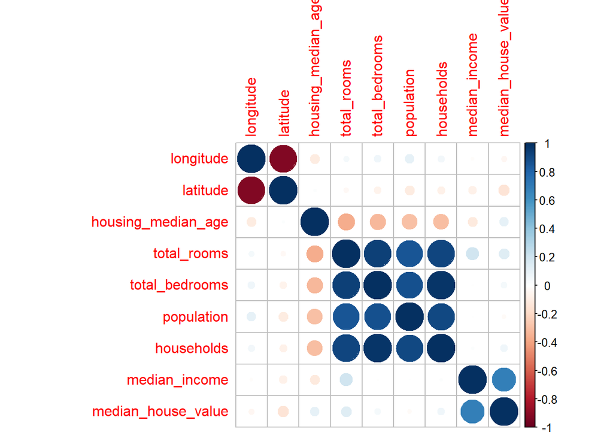

```r
library(corrplot)
require(corrplot)
Mat <- cor(cali_clean[sapply(cali_clean, is.numeric)])
corrplot(Mat)
```

### Visual Representation and correlation of the Dataset - California

##### From the graph we can estimate that the correlation betweeen

##### Median_Income - Median_House_value are highly correlated

##### Getting the correlation values for each predictors and the output value(median_house_value)

##### Features having highest correlation among the predictors

```r
cor(cali_clean$total_rooms, cali_clean$households)
```

```
## [1] 0.9189915
```

```r
cor(cali_clean$population,cali_clean$total_rooms)
```

```
## [1] 0.8572813
```

```r
cor(cali_clean$population,cali_clean$households)
```

```
## [1] 0.9071859
```

##### => Correlation between the output value(median_house_value) and all other predictors

```r
cor(cali_clean$median_income,cali_clean$median_house_value)
```

```
## [1] 0.6883555
```

```r
cor(cali_clean$longitude,cali_clean$median_house_value)
```

```
## [1] -0.04539822
```

```r
cor(cali_clean$latitude,cali_clean$median_house_value)
```

```
## [1] -0.1446382
```

```r
cor(cali_clean$housing_median_age,cali_clean$median_house_value)
```

```
## [1] 0.106432
```

```r
cor(cali_clean$total_rooms,cali_clean$median_house_value)
```

```
## [1] 0.1332941
```

```r
cor(cali_clean$total_bedrooms,cali_clean$median_house_value)
```

```
## [1] 0.04968618
```

```r
cor(cali_clean$population,cali_clean$median_house_value)
```

```
## [1] -0.02529973
```

```r
cor(cali_clean$households,cali_clean$median_house_value)
```

```
## [1] 0.06489355
```

#### Plotting the housing_value based on the latitude, longitude and population

##### This plot shows that the region with the highest population has high housing value

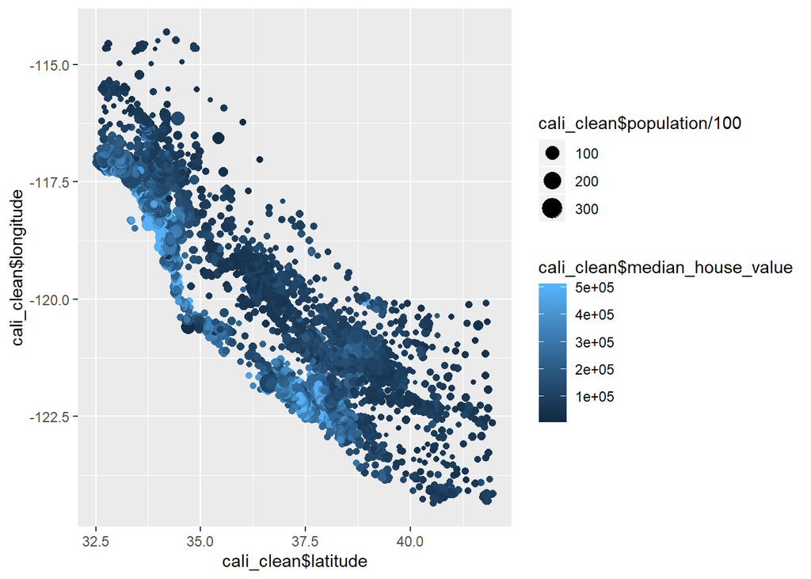

```r
ggplot(data = cali_clean,mapping = aes(cali_clean$latitude,y=cali_clean$longitude, color = cali_clean$median_house_value, size = cali_clean$population/100))+geom_point()
```

##### => Plotting the point ggplot of all predictors vs the housing value

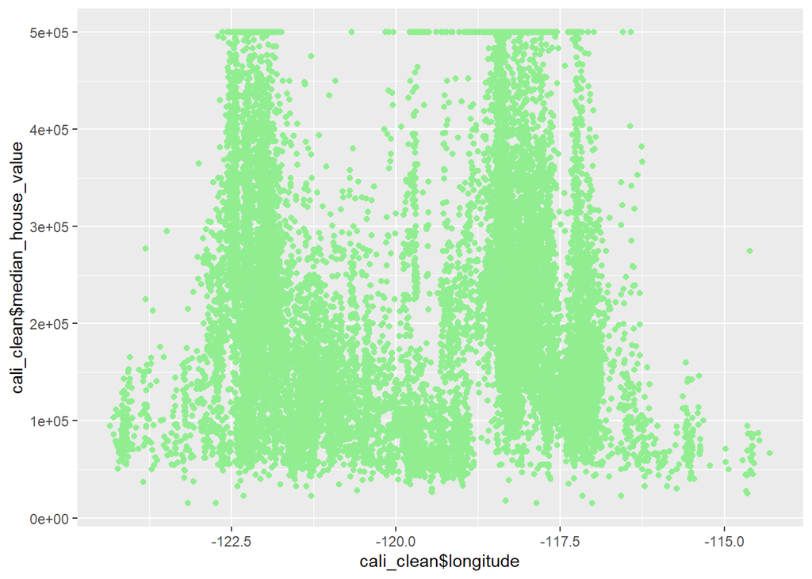

```r
ggplot(data = cali_clean,mapping= aes(cali_clean$longitude, cali_clean$median_house_value))+geom_point(color = "light green")
```

##### This graph concludes that the median_house_value is higher from -122.5 to -117.5 longitude. And the number of houses are more with median_house_value around 1e+05 to 3e+05 and longitude from -122.4 to -117.5

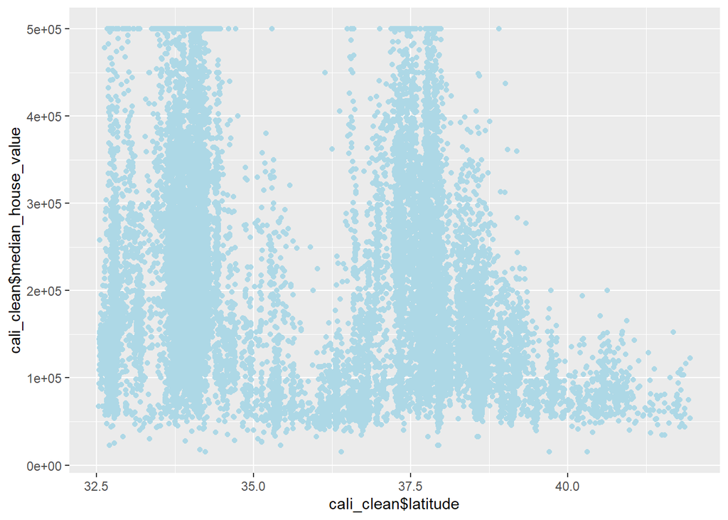

```r
ggplot(data = cali_clean,mapping= aes(cali_clean$latitude, cali_clean$median_house_value))+geom_point(color = "light blue")
```

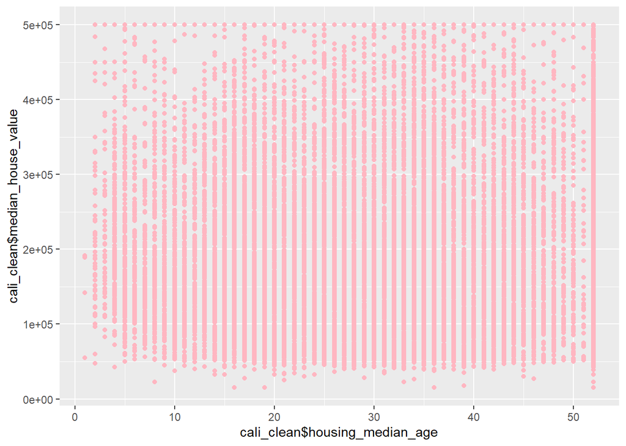

```r
ggplot(data = cali_clean,mapping= aes(cali_clean$housing_median_age, cali_clean$median_house_value))+geom_point(color = "light pink")
```

##### This graph shows that the median_house_value is same for all ages of houses. The houses are spread over all values of the houses and different age

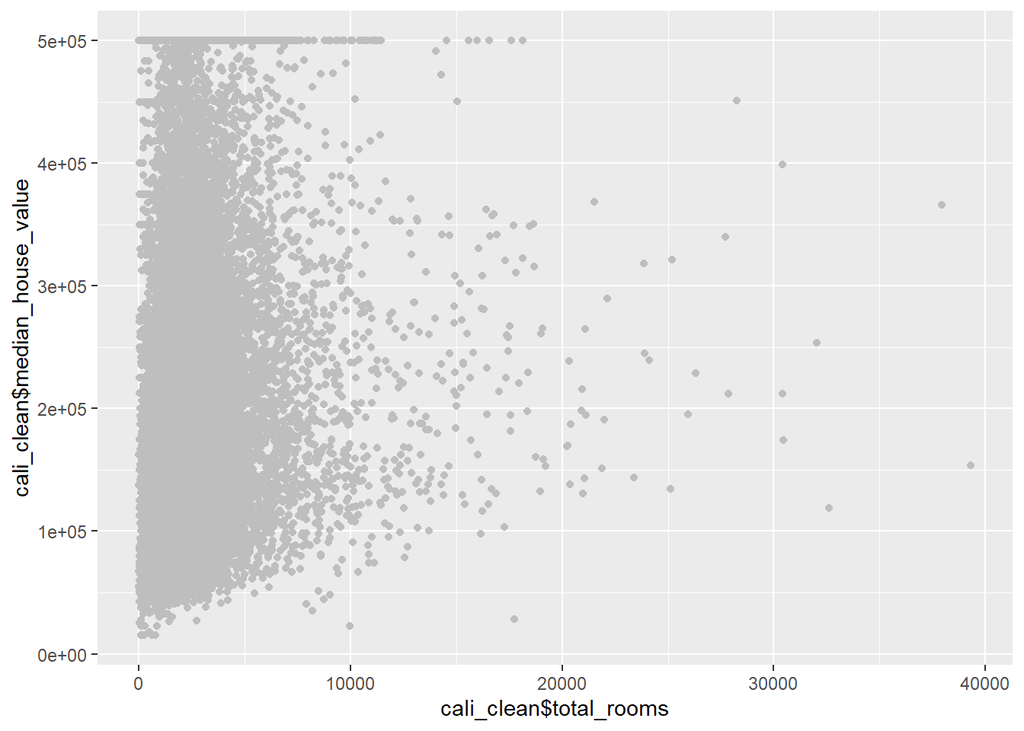

```r
ggplot(data = cali_clean,mapping= aes(cali_clean$total_rooms, cali_clean$median_house_value))+geom_point(color = "grey")
```

##### Almost 90% of the house area have 0 to 5000 rooms in a particular area. The median_house_value is evenly distributed for the area with total_rooms from 0 to 5000.

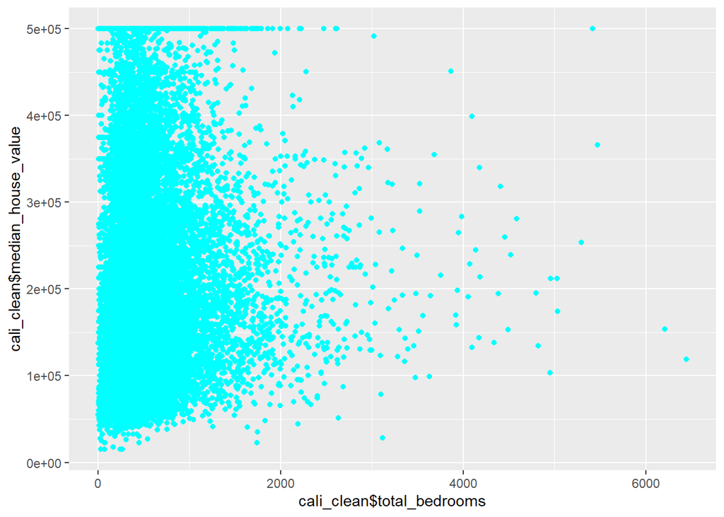

```r
ggplot(data = cali_clean,mapping= aes(cali_clean$total_bedrooms, cali_clean$median_house_value))+geom_point(color = "cyan")
```

##### Almost 80% of the house area have 0 to 1000 bedrooms in a particular area. The median_house_value is evenly distributed for the area with total_bedrooms from 0 to 1000.

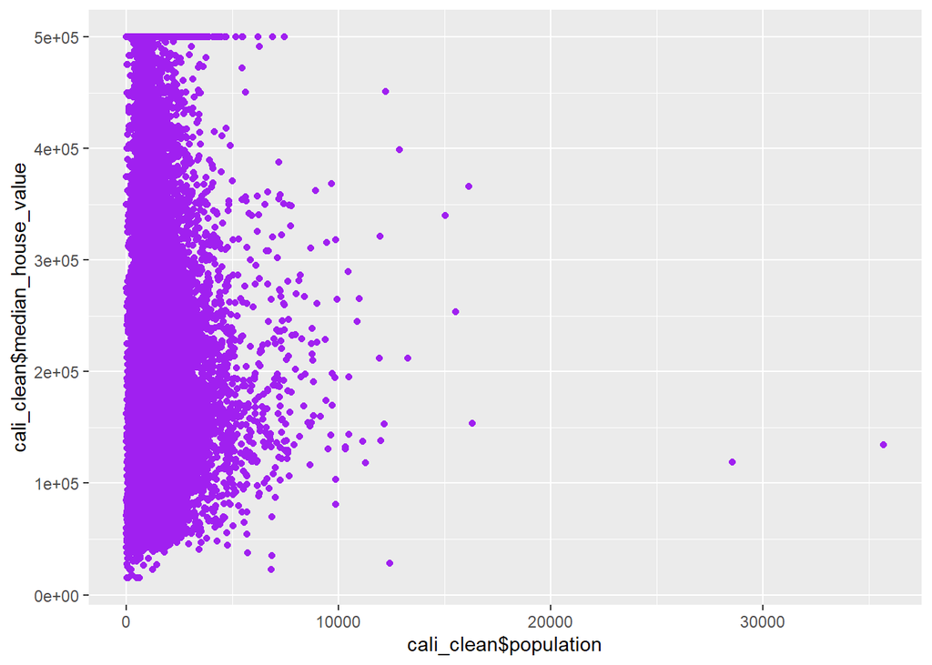

```r
ggplot(data = cali_clean,mapping= aes(cali_clean$population, cali_clean$median_house_value))+geom_point(color = "purple")
```

##### Almost 92% of the house area have 0 to 5000 population count in a particular area. The median_house_value is evenly distributed for the area with population count from 0 to 5000

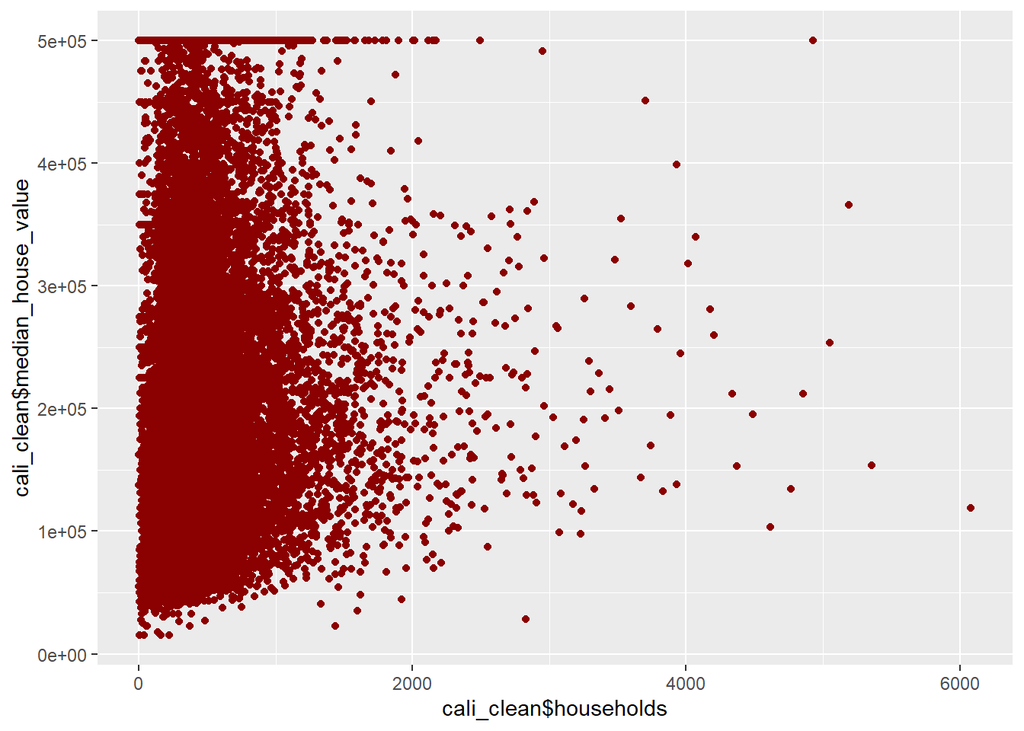

```r
ggplot(data = cali_clean,mapping= aes(cali_clean$households, cali_clean$median_house_value))+geom_point(color = "dark red")
```

##### Almost 90% of the house area have 0 to 1000 households in a particular area. The median_house_value is evenly distributed for the area with households from 0 to 1000.

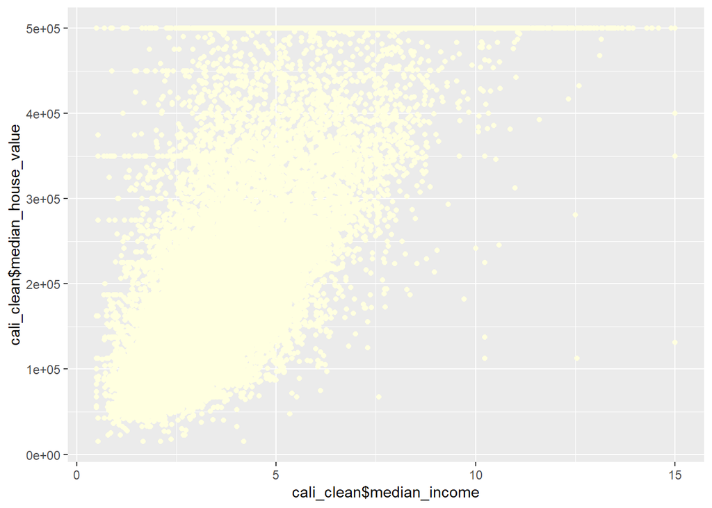

```r
ggplot(data = cali_clean,mapping= aes(cali_clean$median_income, cali_clean$median_house_value))+geom_point(color = "light yellow")
```

##### The graph is linear for the house_value and median_income. The people who gets high income have bought houses with high house_value. The median_house_value gradually increases with increase in house_value.

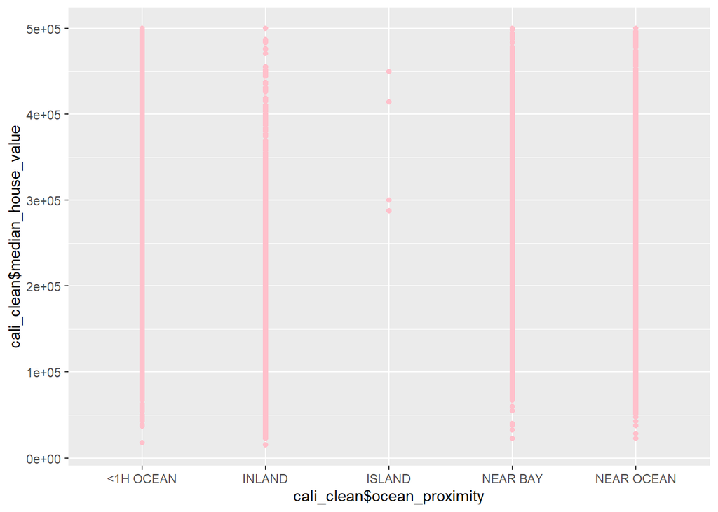

```r
ggplot(data = cali_clean,mapping= aes(cali_clean$ocean_proximity, cali_clean$median_house_value))+geom_point(color = "pink")
```

#### => Finding the concentration of house values based on the ocean proximity

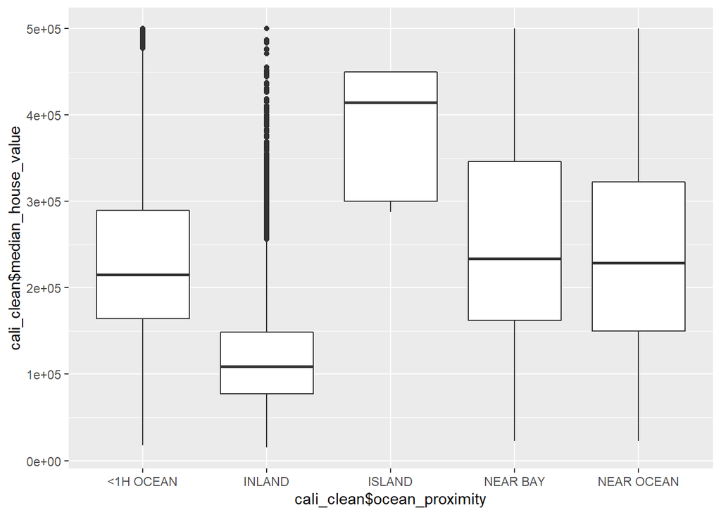

```r
ggplot(data = cali_clean,mapping = aes(x = cali_clean$ocean_proximity, y= cali_clean$median_house_value))+geom_boxplot()
```

##### We can conclude that the there are less number of houses in near ocean and near bay and exactly 5 houses in island

##### But the Median_house_value increases for the houses near ocean and near bay than the houses in the <1HOcean and Inland

#### => Number of houses in each category of ocean proximity

```r
group_ocean = cali_clean %>% group_by(ocean_proximity) %>% summarise(Number = n()) %>% arrange(desc(Number))
group_ocean
```

```
## # A tibble: 5 x 2
##   ocean_proximity Number
##   <fct>            <int>
## 1 <1H OCEAN         9034
## 2 INLAND            6496
## 3 NEAR OCEAN        2628
## 4 NEAR BAY          2270
## 5 ISLAND               5
```

##### We can conclude that there are less houses near the ocean and bay and exactly 5 houses in the island

#### => Top 10 costliest houses in the california housing data

```r
cost = cali_clean %>% filter(!is.na(median_house_value)) %>% arrange(desc(median_house_value)) %>% head(10)
cost
```

```
##    longitude latitude housing_median_age total_rooms total_bedrooms population
## 1    -122.27    37.80                 52         249             78        396
## 2    -122.25    37.87                 52         609            236       1349
## 3    -122.24    37.86                 52        1668            225        517
## 4    -122.24    37.85                 52        3726            474       1366
## 5    -122.23    37.83                 52        2990            379        947
## 6    -122.22    37.82                 39        2492            310        808
## 7    -122.22    37.82                 42        2991            335       1018
## 8    -122.23    37.82                 52        3242            366       1001
## 9    -122.23    37.82                 52        3494            396       1192
## 10   -122.23    37.82                 52        1611            203        556
##    households median_income median_house_value ocean_proximity
## 1          85        1.2434             500001        NEAR BAY
## 2         250        1.1696             500001        NEAR BAY
## 3         214        7.8521             500001        NEAR BAY
## 4         496        9.3959             500001        NEAR BAY
## 5         361        7.8772             500001        NEAR BAY
## 6         315       11.8603             500001        NEAR BAY
## 7         335       13.4990             500001        NEAR BAY
## 8         352       12.2138             500001        NEAR BAY
## 9         383       12.3804             500001        NEAR BAY
## 10        179        8.7477             500001        NEAR BAY
```

```r
rooms = trunc(cali_clean$total_rooms/cali_clean$households)
bedrooms = trunc(cali_clean$total_bedrooms/cali_clean$total_rooms)
popu_per_house = trunc(cali_clean$population/cali_clean$households)
```

##### Adding the additional columns(rooms_per_household, bedrooms_per_room, population_per_husehold) in the cali_full dataframe

##### Splitting the data into the smaller dataset with respect to every household and population

```r
cali_full = cali_clean %>% add_column(rooms = rooms,bedrooms = bedrooms, pop_per_house = popu_per_house)
```

##### => Again finding the correlation between the predcitors and the newly added columns

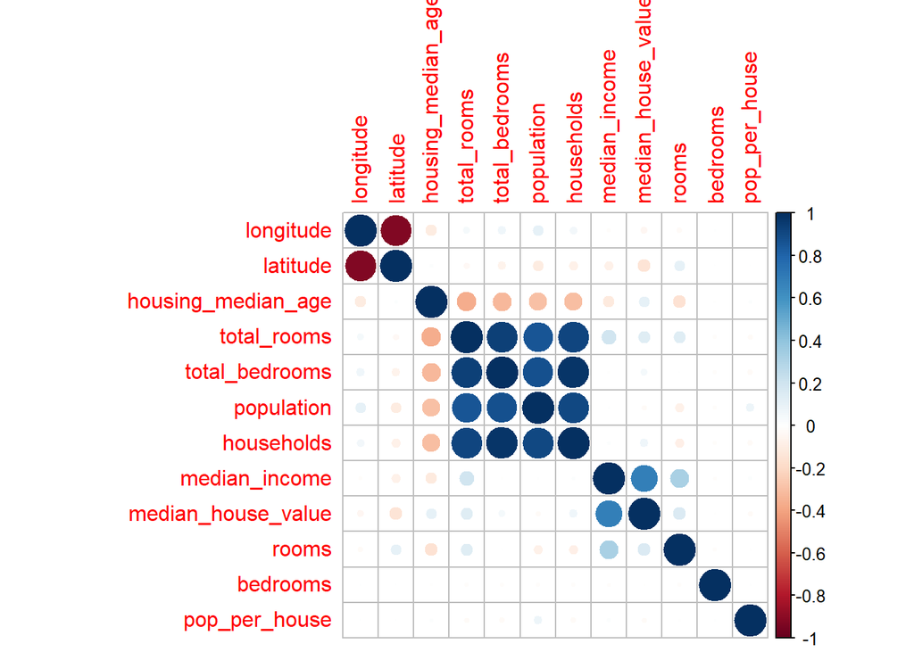

```r
matrix <- cor(cali_full[sapply(cali_full, is.numeric)])
corrplot(matrix)
```

```r
cor(matrix)
```

```
##                        longitude    latitude housing_median_age total_rooms
## longitude           1.0000000000 -0.98144232        -0.18560762  0.14161045
## latitude           -0.9814423246  1.00000000         0.10672804 -0.12179737
## housing_median_age -0.1856076195  0.10672804         1.00000000 -0.75046065
## total_rooms         0.1416104506 -0.12179737        -0.75046065  1.00000000
## total_bedrooms      0.1658263736 -0.14011352        -0.69693145  0.98650546
## population          0.2035423324 -0.17615988        -0.68441755  0.97013502
## households          0.1615291972 -0.14274025        -0.67889602  0.98285046
## median_income      -0.0006528726 -0.10613198        -0.14303440 -0.02771175
## median_house_value  0.0012360285 -0.15879449         0.09101670 -0.08072260
## rooms              -0.1234104348  0.16565900        -0.21599125 -0.10244660
## bedrooms           -0.0065163600  0.01934191         0.04322066 -0.23655525
## pop_per_house      -0.0062305844  0.02071009         0.06267989 -0.23979760
##                    total_bedrooms population households median_income
## longitude               0.1658264  0.2035423  0.1615292 -0.0006528726
## latitude               -0.1401135 -0.1761599 -0.1427403 -0.1061319837
## housing_median_age     -0.6969314 -0.6844175 -0.6788960 -0.1430343952
## total_rooms             0.9865055  0.9701350  0.9828505 -0.0277117515
## total_bedrooms          1.0000000  0.9886538  0.9982912 -0.1702024466
## population              0.9886538  1.0000000  0.9911631 -0.2011689005
## households              0.9982912  0.9911631  1.0000000 -0.1653555078
## median_income          -0.1702024 -0.2011689 -0.1653555  1.0000000000
## median_house_value     -0.1803002 -0.2248021 -0.1664323  0.8852253895
## rooms                  -0.2177188 -0.2756743 -0.2615215  0.4801820119
## bedrooms               -0.2087264 -0.2040689 -0.2056358 -0.1715180939
## pop_per_house          -0.2155424 -0.1370039 -0.2101102 -0.1422231415
##                    median_house_value      rooms    bedrooms pop_per_house
## longitude                 0.001236029 -0.1234104 -0.00651636  -0.006230584
## latitude                 -0.158794486  0.1656590  0.01934191   0.020710093
## housing_median_age        0.091016699 -0.2159912  0.04322066   0.062679886
## total_rooms              -0.080722599 -0.1024466 -0.23655525  -0.239797598
## total_bedrooms           -0.180300241 -0.2177188 -0.20872643  -0.215542353
## population               -0.224802122 -0.2756743 -0.20406894  -0.137003899
## households               -0.166432318 -0.2615215 -0.20563575  -0.210110176
## median_income             0.885225389  0.4801820 -0.17151809  -0.142223141
## median_house_value        1.000000000  0.2535645 -0.16161228  -0.193169329
## rooms                     0.253564468  1.0000000 -0.14655978  -0.128032759
## bedrooms                 -0.161612276 -0.1465598  1.00000000  -0.069676508
## pop_per_house            -0.193169329 -0.1280328 -0.06967651   1.000000000
```

##### => Plotting the graph between the median_house_value, median_income , total_rooms and housing _median_age

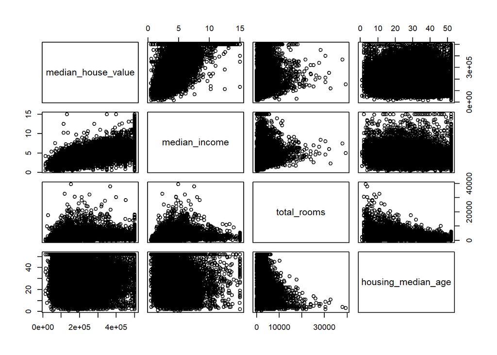

```r
plot(cali_full[,c("median_house_value","median_income","total_rooms","housing_median_age")])
```

##### This plot shows the distribution of median_house_value , median_income , total_rooms and median_housing_age among each other predictor.

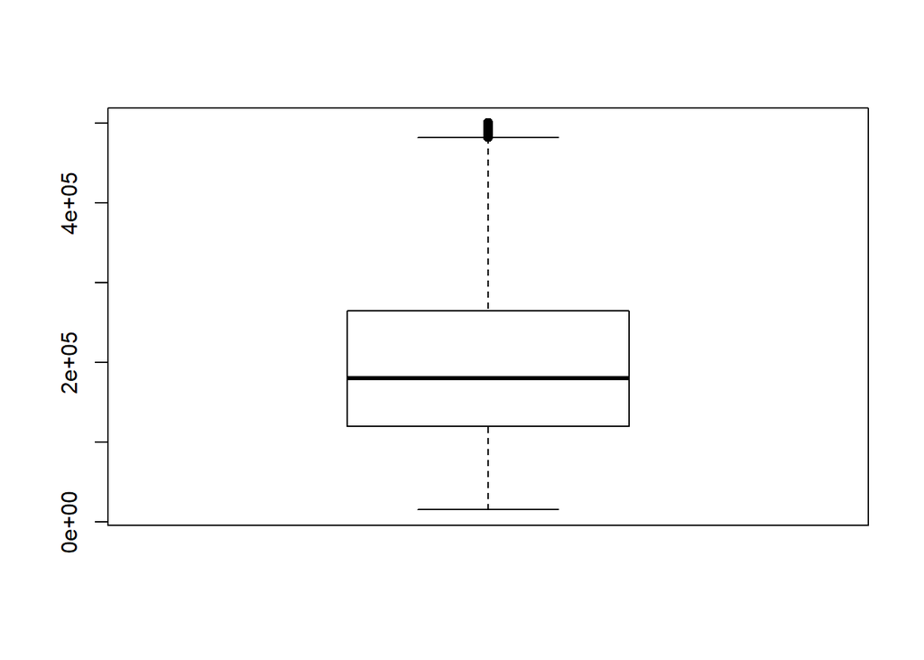

```r
boxplot(cali_full$median_house_value)
```

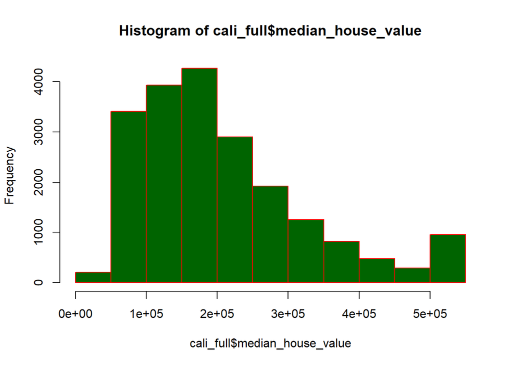

```r
hist(cali_full$median_house_value,col = "dark green", border = 2)
```